# region_analysis_Pacific_Mountain

Li Li

8/3/2021

## Utility functions

```r
library(dplyr)
library(MASS)
library(faraway)
library(lmtest)
# calculate RMSE
rmse = function(actual, predicted) {

  sqrt(mean((actual - predicted) ^ 2))

}


# calculate leave one out cross validation
calc_loocv_rmse = function(model) {

  sqrt(mean((resid(model) / (1 - hatvalues(model))) ^ 2))

}


library(readr)

cars_data = read_csv("used_truck_data_with_region.csv")
cars_data$region = as.factor(cars_data$region)

cars_data$state = as.factor(cars_data$state)




cars_pacific = subset(cars_data, cars_data$region == "Pacific")

cars_mountain = subset(cars_data, cars_data$region == "Mountain")
```

## Pacific Region

```r
set.seed(420420420)

size_num = 5000

cars_idx = sample(nrow(cars_pacific), size_num)

cars_trn = cars_pacific[cars_idx, ]

cars_tst = cars_pacific[-cars_idx, ]


fit_common = lm(price ~ engine_displacement + engine_cylinders + highway_fuel_economy + horsepower + maximum_seating + transmission +
                  mileage + year + wheel_system + power_hp + bed_length +
                  cabin + salvage + franchise_dealer + state, data = cars_trn)


summary(fit_common)
```

```
##
## Call:
## lm(formula = price ~ engine_displacement + engine_cylinders +
##     highway_fuel_economy + horsepower + maximum_seating + transmission +
##     mileage + year + wheel_system + power_hp + bed_length + cabin +
##     salvage + franchise_dealer + state, data = cars_trn)
##
## Residuals:
##    Min     1Q Median     3Q    Max
## -27591  -4633   -333   4054  42076
##
## Coefficients:
##                        Estimate Std. Error t value Pr(>|t|)
## (Intercept)          -2.264e+06  1.392e+05 -16.265  < 2e-16 ***
## engine_displacement  -6.273e-01  3.109e-01  -2.018 0.043674 *
## engine_cylinders      1.578e+03  2.722e+02   5.797 7.17e-09 ***
## highway_fuel_economy  6.069e+02  6.158e+01   9.856  < 2e-16 ***
## horsepower            4.663e+01  3.341e+00  13.960  < 2e-16 ***
## maximum_seating      -1.849e+03  2.298e+02  -8.045 1.07e-15 ***
## transmissionM         1.771e+03  1.040e+03   1.704 0.088523 .
## mileage              -9.615e-02  4.554e-03 -21.113  < 2e-16 ***
## year                  1.136e+03  6.911e+01  16.437  < 2e-16 ***
## wheel_system4X2      -8.785e+03  2.368e+02 -37.094  < 2e-16 ***
## wheel_systemAWD      -5.413e+03  9.861e+02  -5.489 4.24e-08 ***
## wheel_systemFWD      -1.095e+04  2.847e+03  -3.847 0.000121 ***
## wheel_systemRWD      -3.898e+02  8.158e+02  -0.478 0.632757
## power_hp              1.548e+00  2.524e+00   0.613 0.539691
## bed_length           -1.579e+02  1.701e+01  -9.286  < 2e-16 ***
## cabinExtended Cab    -1.217e+03  8.261e+02  -1.473 0.140724
## cabinLarge Crew Cab   2.838e+03  1.834e+03   1.548 0.121786
## cabinNot Listed      -7.475e+02  3.400e+02  -2.198 0.027964 *
## cabinRegular Cab     -3.121e+03  2.157e+03  -1.447 0.148016
## salvageTRUE          -3.054e+03  3.136e+03  -0.974 0.330038
## franchise_dealerTRUE  2.108e+03  3.067e+02   6.873 7.05e-12 ***
## stateHI               2.442e+03  7.001e+03   0.349 0.727273
## stateOR              -1.657e+03  7.862e+02  -2.107 0.035160 *
## stateWA              -1.834e+01  4.347e+02  -0.042 0.966353
## ---
## Signif. codes:  0 '***' 0.001 '**' 0.01 '*' 0.05 '.' 0.1 ' ' 1
##
## Residual standard error: 6939 on 4976 degrees of freedom
## Multiple R-squared:  0.7173, Adjusted R-squared:  0.716
## F-statistic:   549 on 23 and 4976 DF,  p-value: < 2.2e-16
```

```r
n = length(resid(fit_common))

# Apple BIC
fit_reduced = step(fit_common, direction = "backward", trace = 0, k = log(n))

summary(fit_reduced)
```

```
##
## Call:
## lm(formula = price ~ engine_cylinders + highway_fuel_economy +
##     horsepower + maximum_seating + mileage + year + wheel_system +
##     bed_length + franchise_dealer, data = cars_trn)
##
## Residuals:
##    Min     1Q Median     3Q    Max
## -27733  -4613   -312   4028  41735
##
## Coefficients:
##                        Estimate Std. Error t value Pr(>|t|)
## (Intercept)          -2.253e+06  1.365e+05 -16.496  < 2e-16 ***
## engine_cylinders      1.108e+03  1.410e+02   7.859 4.70e-15 ***
## highway_fuel_economy  6.526e+02  5.524e+01  11.813  < 2e-16 ***
## horsepower            4.562e+01  2.837e+00  16.084  < 2e-16 ***
## maximum_seating      -1.657e+03  2.058e+02  -8.052 1.01e-15 ***
## mileage              -9.658e-02  4.541e-03 -21.270  < 2e-16 ***
## year                  1.130e+03  6.779e+01  16.665  < 2e-16 ***
## wheel_system4X2      -8.836e+03  2.253e+02 -39.224  < 2e-16 ***
## wheel_systemAWD      -5.415e+03  9.847e+02  -5.500 4.00e-08 ***
## wheel_systemFWD      -1.094e+04  2.849e+03  -3.839 0.000125 ***
## wheel_systemRWD      -4.029e+02  8.078e+02  -0.499 0.617933
## bed_length           -1.655e+02  1.651e+01 -10.020  < 2e-16 ***
## franchise_dealerTRUE  2.012e+03  3.053e+02   6.589 4.88e-11 ***
## ---
## Signif. codes:  0 '***' 0.001 '**' 0.01 '*' 0.05 '.' 0.1 ' ' 1
##
## Residual standard error: 6947 on 4987 degrees of freedom
## Multiple R-squared:  0.716,  Adjusted R-squared:  0.7154
## F-statistic:  1048 on 12 and 4987 DF,  p-value: < 2.2e-16
```

```r
rmse(cars_trn$price, predict(fit_reduced, cars_trn))
```

```
## [1] 6938.348
```

```r
rmse(cars_tst$price, predict(fit_reduced, cars_tst))
```

```
## [1] 7792.484
```

```r
calc_loocv_rmse(fit_common)
```

```
## [1] Inf
```

```r
calc_loocv_rmse(fit_reduced)
```

```
## [1] 6956.607
```

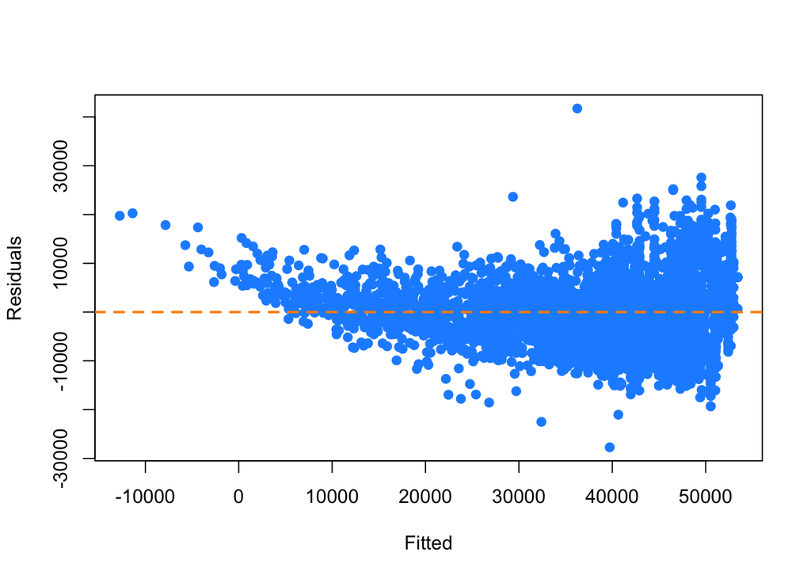

```r
plot(fitted(fit_reduced), resid(fit_reduced), col = "dodgerblue",
     pch = 20, cex = 1.5, xlab = "Fitted", ylab = "Residuals")
abline(h = 0, lty = 2, col = "darkorange", lwd = 2)
```

```r
bptest(fit_reduced)
```

```
##
##  studentized Breusch-Pagan test
##
## data:  fit_reduced
## BP = 498.51, df = 12, p-value < 2.2e-16
```

```r
shapiro.test(resid(fit_reduced))
```

```
##
##  Shapiro-Wilk normality test
##
## data:  resid(fit_reduced)
## W = 0.99054, p-value < 2.2e-16
```

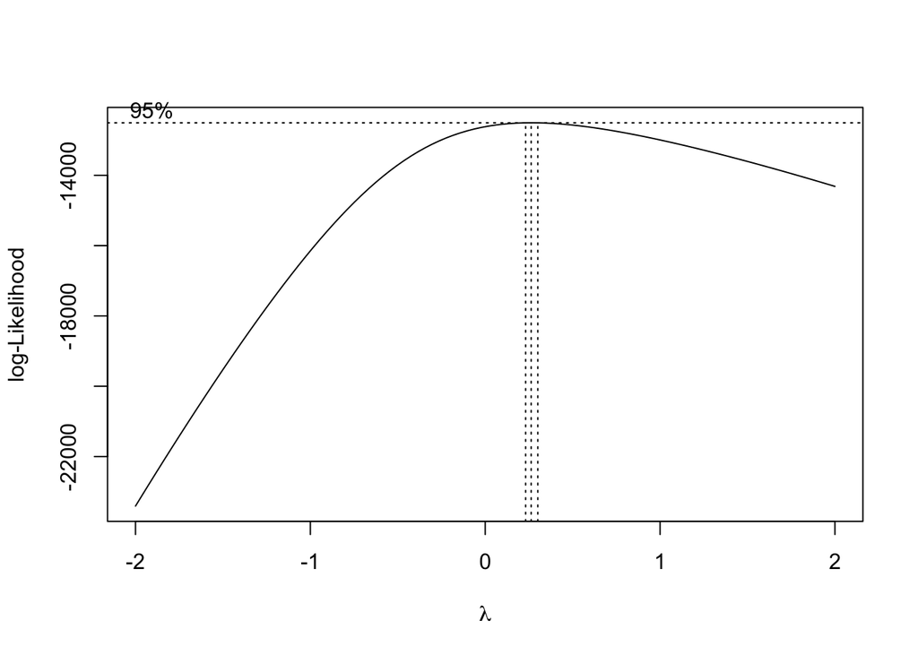

```r
boxcox(fit_reduced, plotit = TRUE)
```

```r
fit_cox = lm((price^0.26 - 1)/0.26 ~ engine_displacement + engine_cylinders +
    highway_fuel_economy + horsepower + maximum_seating + mileage +
    year + wheel_system + bed_length + franchise_dealer, data = cars_trn)

summary(fit_cox)
```

```
##
## Call:
## lm(formula = (price^0.26 - 1)/0.26 ~ engine_displacement + engine_cylinders +
##     highway_fuel_economy + horsepower + maximum_seating + mileage +
##     year + wheel_system + bed_length + franchise_dealer, data = cars_trn)
##
## Residuals:
##      Min       1Q   Median       3Q      Max
## -12.7841  -1.7137  -0.0224   1.7193  14.3967
##
## Coefficients:
##                        Estimate Std. Error t value Pr(>|t|)
## (Intercept)          -1.296e+03  5.212e+01 -24.860  < 2e-16 ***
## engine_displacement  -3.356e-04  1.158e-04  -2.898 0.003769 **
## engine_cylinders      6.538e-01  1.024e-01   6.385 1.87e-10 ***
## highway_fuel_economy  2.485e-01  2.336e-02  10.638  < 2e-16 ***
## horsepower            2.065e-02  1.110e-03  18.610  < 2e-16 ***
## maximum_seating      -3.439e-01  7.950e-02  -4.325 1.55e-05 ***
## mileage              -4.261e-05  1.732e-06 -24.609  < 2e-16 ***
## year                  6.666e-01  2.587e-02  25.764  < 2e-16 ***
## wheel_system4X2      -3.344e+00  8.736e-02 -38.279  < 2e-16 ***
## wheel_systemAWD      -2.051e+00  3.755e-01  -5.462 4.93e-08 ***
## wheel_systemFWD      -3.604e+00  1.086e+00  -3.317 0.000916 ***
## wheel_systemRWD      -2.082e+00  3.080e-01  -6.759 1.55e-11 ***
## bed_length           -7.961e-02  6.325e-03 -12.586  < 2e-16 ***
## franchise_dealerTRUE  5.585e-01  1.164e-01   4.798 1.65e-06 ***
## ---
## Signif. codes:  0 '***' 0.001 '**' 0.01 '*' 0.05 '.' 0.1 ' ' 1
##
## Residual standard error: 2.649 on 4986 degrees of freedom
## Multiple R-squared:  0.8066, Adjusted R-squared:  0.8061
## F-statistic:  1600 on 13 and 4986 DF,  p-value: < 2.2e-16
```

```r
bptest(fit_cox)
```

```
##
##  studentized Breusch-Pagan test
##
## data:  fit_cox
## BP = 464.12, df = 13, p-value < 2.2e-16
```

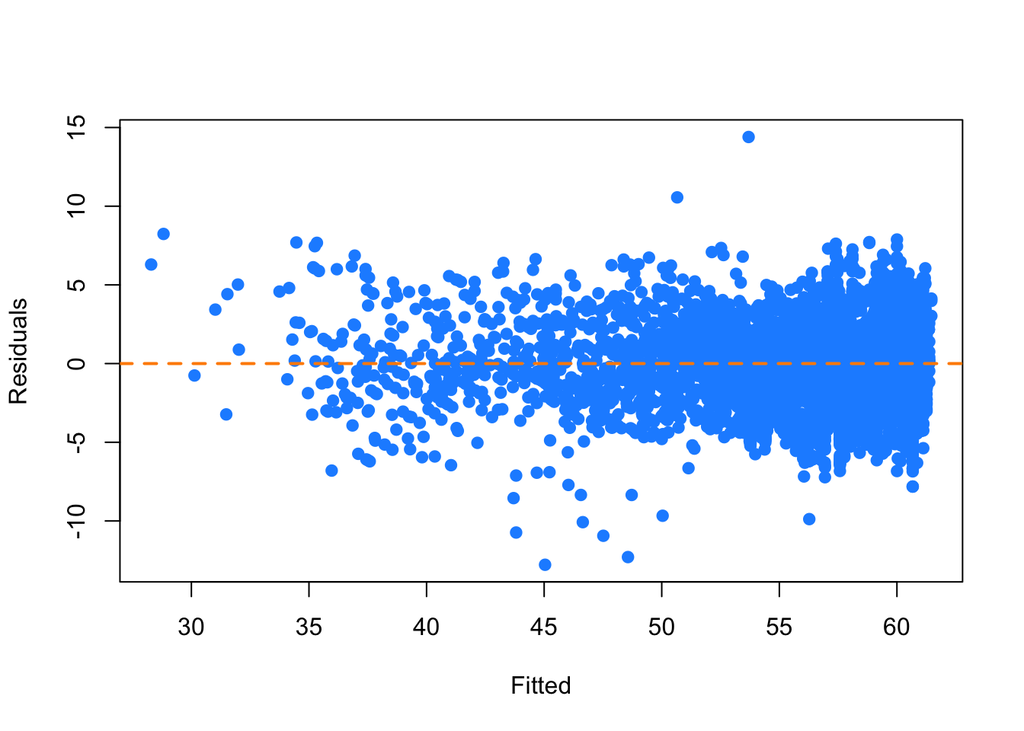

```r
plot(fitted(fit_cox), resid(fit_cox), col = "dodgerblue",
     pch = 20, cex = 1.5, xlab = "Fitted", ylab = "Residuals")
abline(h = 0, lty = 2, col = "darkorange", lwd = 2)
```

We can consider to choose between 0 and 0.3, since the Log-likelihood is almost the same. Apply transformation to price

```r
fit_reduced2 = lm(log(price) ~ engine_displacement + engine_cylinders +
    highway_fuel_economy + horsepower + maximum_seating + mileage +
    year + wheel_system + bed_length + franchise_dealer, data = cars_trn)

summary(fit_reduced2)
```

```
##
## Call:
## lm(formula = log(price) ~ engine_displacement + engine_cylinders +
##     highway_fuel_economy + horsepower + maximum_seating + mileage +
##     year + wheel_system + bed_length + franchise_dealer, data = cars_trn)
##
## Residuals:
##     Min      1Q  Median      3Q     Max
## -1.0866 -0.1105 -0.0013  0.1160  0.8950
##
## Coefficients:
##                        Estimate Std. Error t value Pr(>|t|)
## (Intercept)          -9.063e+01  3.472e+00 -26.104  < 2e-16 ***
## engine_displacement  -2.301e-05  7.714e-06  -2.983  0.00286 **
## engine_cylinders      4.139e-02  6.821e-03   6.067 1.40e-09 ***
## highway_fuel_economy  1.650e-02  1.556e-03  10.601  < 2e-16 ***
## horsepower            1.405e-03  7.394e-05  19.002  < 2e-16 ***
## maximum_seating      -1.243e-02  5.296e-03  -2.347  0.01899 *
## mileage              -2.879e-06  1.154e-07 -24.960  < 2e-16 ***
## year                  4.991e-02  1.724e-03  28.955  < 2e-16 ***
## wheel_system4X2      -2.117e-01  5.820e-03 -36.384  < 2e-16 ***
## wheel_systemAWD      -1.328e-01  2.501e-02  -5.308 1.15e-07 ***
## wheel_systemFWD      -2.096e-01  7.238e-02  -2.895  0.00380 **
## wheel_systemRWD      -2.122e-01  2.052e-02 -10.342  < 2e-16 ***
## bed_length           -5.529e-03  4.214e-04 -13.123  < 2e-16 ***
## franchise_dealerTRUE  2.656e-02  7.755e-03   3.425  0.00062 ***
## ---
## Signif. codes:  0 '***' 0.001 '**' 0.01 '*' 0.05 '.' 0.1 ' ' 1
##
## Residual standard error: 0.1765 on 4986 degrees of freedom
## Multiple R-squared:  0.8261, Adjusted R-squared:  0.8256
## F-statistic:  1822 on 13 and 4986 DF,  p-value: < 2.2e-16
```

```r
rmse(log(cars_trn$price), predict(fit_reduced2, cars_trn))
```

```
## [1] 0.1762315
```

```r
rmse(log(cars_tst$price), predict(fit_reduced2, cars_tst))
```

```
## [1] 0.17583
```

```r
calc_loocv_rmse(fit_reduced2)
```

```
## [1] 0.1770333
```

From the final model, R squared improves to 0.82, 10 predictors, RMSE is 0.17

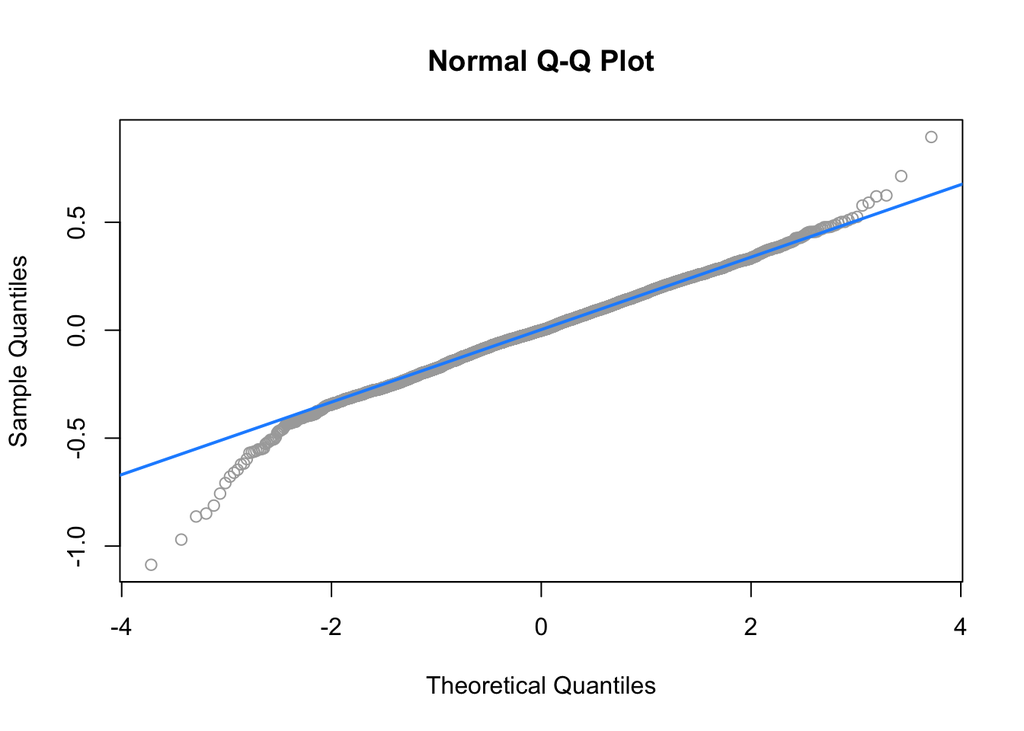

```r
qqnorm(resid(fit_reduced2), col = "darkgrey")
qqline(resid(fit_reduced2), col = "dodgerblue", lwd = 2)
```

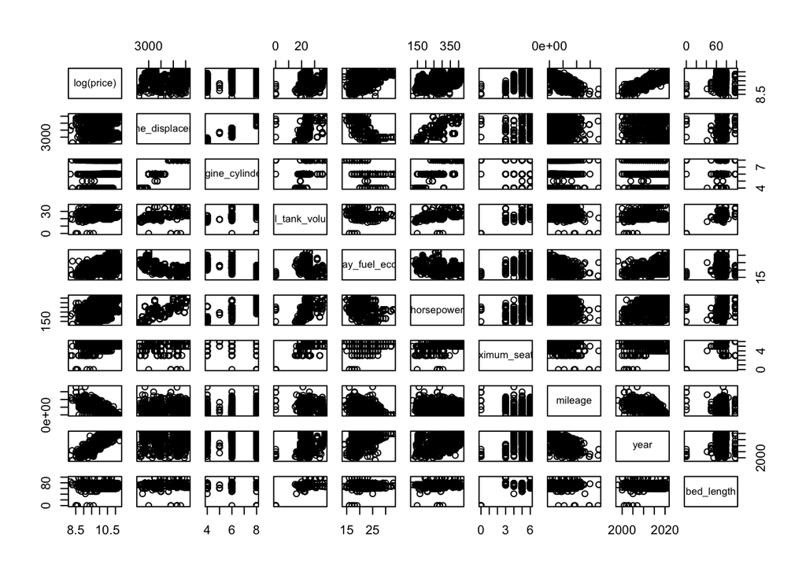

```r
pairs(log(price) ~ engine_displacement + engine_cylinders + fuel_tank_volume + highway_fuel_economy + horsepower + maximum_seating + mileage + year + bed_length, data = cars_trn)
```

```r
fit_col = lm(log(price) ~ engine_displacement + engine_cylinders +
    highway_fuel_economy + horsepower + maximum_seating + mileage +
    year + wheel_system + bed_length + franchise_dealer + year:bed_length + year:mileage + maximum_seating:bed_length +
      engine_cylinders:highway_fuel_economy + engine_cylinders:horsepower + engine_displacement:engine_cylinders +       engine_displacement:highway_fuel_economy, data = cars_trn)

summary(fit_col)
```

```
##
## Call:
## lm(formula = log(price) ~ engine_displacement + engine_cylinders +
##     highway_fuel_economy + horsepower + maximum_seating + mileage +
##     year + wheel_system + bed_length + franchise_dealer + year:bed_length +
##     year:mileage + maximum_seating:bed_length + engine_cylinders:highway_fuel_economy +
##     engine_cylinders:horsepower + engine_displacement:engine_cylinders +
##     engine_displacement:highway_fuel_economy, data = cars_trn)
##
## Residuals:
##     Min      1Q  Median      3Q     Max
## -0.9923 -0.1027  0.0019  0.1075  0.6862
##
## Coefficients:
##                                            Estimate Std. Error t value Pr(>|t|)
## (Intercept)                              -5.738e+01  1.283e+01  -4.472 7.94e-06
## engine_displacement                       7.059e-04  6.096e-05  11.579  < 2e-16
## engine_cylinders                         -8.873e-01  6.040e-02 -14.691  < 2e-16
## highway_fuel_economy                     -8.891e-02  9.399e-03  -9.460  < 2e-16
## horsepower                                1.270e-03  4.052e-04   3.135  0.00173
## maximum_seating                           1.091e-01  2.066e-02   5.282 1.33e-07
## mileage                                  -1.854e-04  2.683e-05  -6.912 5.38e-12
## year                                      3.458e-02  6.413e-03   5.391 7.32e-08
## wheel_system4X2                          -1.866e-01  5.832e-03 -31.988  < 2e-16
## wheel_systemAWD                          -1.138e-01  2.403e-02  -4.736 2.24e-06
## wheel_systemFWD                          -1.888e-01  6.933e-02  -2.723  0.00649
## wheel_systemRWD                          -1.251e-01  2.148e-02  -5.826 6.05e-09
## bed_length                               -4.044e-01  1.802e-01  -2.244  0.02487
## franchise_dealerTRUE                      3.918e-02  7.580e-03   5.170 2.44e-07
## year:bed_length                           2.021e-04  8.998e-05   2.246  0.02477
## mileage:year                              9.075e-08  1.332e-08   6.812 1.08e-11
## maximum_seating:bed_length               -1.918e-03  3.016e-04  -6.360 2.20e-10
## engine_cylinders:highway_fuel_economy     3.897e-02  2.390e-03  16.308  < 2e-16
## engine_cylinders:horsepower               2.491e-05  6.641e-05   0.375  0.70761
## engine_displacement:engine_cylinders      1.688e-05  5.385e-06   3.135  0.00173
## engine_displacement:highway_fuel_economy -3.955e-05  2.172e-06 -18.209  < 2e-16
##
## (Intercept)                              ***
## engine_displacement                      ***
## engine_cylinders                         ***
```

[output cut: 9 more lines]

```
## bed_length                               *
## franchise_dealerTRUE                     ***
## year:bed_length                          *
## mileage:year                             ***
## maximum_seating:bed_length               ***
## engine_cylinders:highway_fuel_economy    ***
## engine_cylinders:horsepower
## engine_displacement:engine_cylinders     **
## engine_displacement:highway_fuel_economy ***
## ---
## Signif. codes:  0 '***' 0.001 '**' 0.01 '*' 0.05 '.' 0.1 ' ' 1
##
## Residual standard error: 0.1688 on 4979 degrees of freedom
## Multiple R-squared:  0.8411, Adjusted R-squared:  0.8405
## F-statistic:  1318 on 20 and 4979 DF,  p-value: < 2.2e-16
```

```r
anova(fit_reduced2, fit_col)
```

```
## Analysis of Variance Table
##
## Model 1: log(price) ~ engine_displacement + engine_cylinders + highway_fuel_economy +
##     horsepower + maximum_seating + mileage + year + wheel_system +
##     bed_length + franchise_dealer
## Model 2: log(price) ~ engine_displacement + engine_cylinders + highway_fuel_economy +
##     horsepower + maximum_seating + mileage + year + wheel_system +
##     bed_length + franchise_dealer + year:bed_length + year:mileage +
##     maximum_seating:bed_length + engine_cylinders:highway_fuel_economy +
##     engine_cylinders:horsepower + engine_displacement:engine_cylinders +
##     engine_displacement:highway_fuel_economy
##   Res.Df    RSS Df Sum of Sq      F    Pr(>F)
## 1   4986 155.29
## 2   4979 141.85  7    13.439 67.388 < 2.2e-16 ***
## ---
## Signif. codes:  0 '***' 0.001 '**' 0.01 '*' 0.05 '.' 0.1 ' ' 1
```

```r
rmse(log(cars_trn$price), predict(fit_col, cars_trn))
```

```
## [1] 0.1684332
```

```r
rmse(log(cars_tst$price), predict(fit_col, cars_tst))
```

```
## [1] 0.1687245
```

```r
calc_loocv_rmse(fit_col)
```

```
## [1] 0.1697349
```

Adding 7 colinear terms, R squared improved to 0.84, RMSE is 0.16

## Mountain Region

```r
set.seed(420420420)

size_num = 12000

cars_idx = sample(nrow(cars_mountain), size_num)

cars_trn = cars_mountain[cars_idx, ]

cars_tst = cars_mountain[-cars_idx, ]


fit_common = lm(price ~ engine_displacement + engine_cylinders + highway_fuel_economy + horsepower + maximum_seating + transmission +
                  mileage + year + wheel_system + power_hp + bed_length +
                  cabin + salvage + franchise_dealer + state, data = cars_trn)


summary(fit_common)
```

```
##
## Call:
## lm(formula = price ~ engine_displacement + engine_cylinders +
##     highway_fuel_economy + horsepower + maximum_seating + transmission +
##     mileage + year + wheel_system + power_hp + bed_length + cabin +
##     salvage + franchise_dealer + state, data = cars_trn)
##
## Residuals:
##    Min     1Q Median     3Q    Max
## -22277  -4759   -708   4085  75114
##
## Coefficients:
##                        Estimate Std. Error t value Pr(>|t|)
## (Intercept)          -3.242e+06  8.023e+04 -40.405  < 2e-16 ***
## engine_displacement  -2.565e-01  2.123e-01  -1.209  0.22680
## engine_cylinders      3.507e+02  2.045e+02   1.715  0.08640 .
## highway_fuel_economy  2.382e+02  4.185e+01   5.691 1.30e-08 ***
## horsepower            5.027e+01  2.236e+00  22.480  < 2e-16 ***
## maximum_seating      -2.733e+03  1.504e+02 -18.167  < 2e-16 ***
## transmissionM         5.517e+02  6.486e+02   0.851  0.39499
## mileage              -7.130e-02  2.445e-03 -29.167  < 2e-16 ***
## year                  1.624e+03  3.992e+01  40.688  < 2e-16 ***
## wheel_system4X2      -8.222e+03  2.073e+02 -39.659  < 2e-16 ***
## wheel_systemAWD      -4.450e+03  5.035e+02  -8.839  < 2e-16 ***
## wheel_systemFWD      -1.043e+04  2.168e+03  -4.812 1.51e-06 ***
## wheel_systemRWD       2.033e+03  7.150e+02   2.844  0.00447 **
## power_hp              9.672e+00  1.636e+00   5.911 3.50e-09 ***
## bed_length           -8.742e+01  1.144e+01  -7.643 2.29e-14 ***
## cabinExtended Cab    -9.799e+02  5.570e+02  -1.759  0.07856 .
## cabinLarge Crew Cab   2.700e+03  8.950e+02   3.017  0.00256 **
## cabinNot Listed       5.802e+02  2.026e+02   2.864  0.00419 **
## cabinRegular Cab     -1.163e+03  2.641e+03  -0.441  0.65958
## salvageTRUE          -6.038e+03  8.973e+02  -6.729 1.79e-11 ***
## franchise_dealerTRUE  1.530e+03  2.114e+02   7.239 4.79e-13 ***
## stateCO              -2.006e+02  1.905e+02  -1.053  0.29240
## stateID              -2.595e+02  2.556e+02  -1.015  0.30998
## stateMT               3.698e+02  2.823e+02   1.310  0.19014
## stateNM               5.958e+02  2.478e+02   2.404  0.01623 *
## stateNV               1.045e+03  2.288e+02   4.567 5.00e-06 ***
## stateUT              -4.932e+02  2.320e+02  -2.126  0.03353 *
## stateWY               2.221e+03  4.166e+02   5.331 9.95e-08 ***
## ---
## Signif. codes:  0 '***' 0.001 '**' 0.01 '*' 0.05 '.' 0.1 ' ' 1
##
## Residual standard error: 6821 on 11972 degrees of freedom
## Multiple R-squared:  0.7199, Adjusted R-squared:  0.7193
## F-statistic:  1140 on 27 and 11972 DF,  p-value: < 2.2e-16
```

```r
n = length(resid(fit_common))

# Apple BIC
fit_reduced = step(fit_common, direction = "backward", trace = 0, k = log(n))

summary(fit_reduced)
```

```
##
## Call:
## lm(formula = price ~ highway_fuel_economy + horsepower + maximum_seating +
##     mileage + year + wheel_system + power_hp + bed_length + salvage +
##     franchise_dealer + state, data = cars_trn)
##
## Residuals:
##    Min     1Q Median     3Q    Max
## -22125  -4807   -693   4054  75365
##
## Coefficients:
##                        Estimate Std. Error t value Pr(>|t|)
## (Intercept)          -3.265e+06  7.958e+04 -41.029  < 2e-16 ***
## highway_fuel_economy  2.153e+02  3.741e+01   5.756 8.80e-09 ***
## horsepower            5.088e+01  1.841e+00  27.639  < 2e-16 ***
## maximum_seating      -2.701e+03  1.477e+02 -18.291  < 2e-16 ***
## mileage              -7.122e-02  2.442e-03 -29.161  < 2e-16 ***
## year                  1.637e+03  3.961e+01  41.320  < 2e-16 ***
## wheel_system4X2      -8.210e+03  2.040e+02 -40.257  < 2e-16 ***
## wheel_systemAWD      -4.406e+03  5.031e+02  -8.758  < 2e-16 ***
## wheel_systemFWD      -1.030e+04  2.168e+03  -4.749 2.06e-06 ***
## wheel_systemRWD       2.011e+03  7.141e+02   2.816  0.00486 **
## power_hp              9.817e+00  1.561e+00   6.288 3.32e-10 ***
## bed_length           -9.316e+01  1.113e+01  -8.371  < 2e-16 ***
## salvageTRUE          -6.032e+03  8.975e+02  -6.722 1.88e-11 ***
## franchise_dealerTRUE  1.639e+03  2.068e+02   7.927 2.45e-15 ***
## stateCO              -1.543e+02  1.893e+02  -0.815  0.41491
## stateID              -3.213e+02  2.547e+02  -1.261  0.20717
## stateMT               2.688e+02  2.798e+02   0.961  0.33665
## stateNM               6.174e+02  2.479e+02   2.491  0.01277 *
## stateNV               1.053e+03  2.285e+02   4.606 4.15e-06 ***
## stateUT              -4.618e+02  2.314e+02  -1.996  0.04598 *
## stateWY               2.207e+03  4.169e+02   5.294 1.22e-07 ***
## ---
## Signif. codes:  0 '***' 0.001 '**' 0.01 '*' 0.05 '.' 0.1 ' ' 1
##
## Residual standard error: 6827 on 11979 degrees of freedom
## Multiple R-squared:  0.7193, Adjusted R-squared:  0.7188
## F-statistic:  1535 on 20 and 11979 DF,  p-value: < 2.2e-16
```

```r
rmse(cars_trn$price, predict(fit_reduced, cars_trn))
```

```
## [1] 6820.959
```

```r
rmse(cars_tst$price, predict(fit_reduced, cars_tst))
```

```
## [1] 6884.981
```

```r
calc_loocv_rmse(fit_common)
```

```
## [1] 6857.33
```

```r
calc_loocv_rmse(fit_reduced)
```

```
## [1] 6861.342
```

Reduced model for Mountain region is price ~ highway_fuel_economy + horsepower + maximum_seating + mileage + year + wheel_system + power_hp + bed_length + salvage + franchise_dealer + state Predictors reduced to 11, R squared 0.72

Apply transformation to price

```r
fit_reduced2 = lm(log(price) ~ highway_fuel_economy + horsepower + maximum_seating +
    mileage + year + wheel_system + power_hp + bed_length + salvage +
    franchise_dealer + state, data = cars_trn)

summary(fit_reduced2)
```

```
##
## Call:
## lm(formula = log(price) ~ highway_fuel_economy + horsepower +
##     maximum_seating + mileage + year + wheel_system + power_hp +
##     bed_length + salvage + franchise_dealer + state, data = cars_trn)
##
## Residuals:
##     Min      1Q  Median      3Q     Max
## -1.2113 -0.1094 -0.0011  0.1110  2.2409
##
## Coefficients:
##                        Estimate Std. Error t value Pr(>|t|)
## (Intercept)          -1.263e+02  1.932e+00 -65.351  < 2e-16 ***
## highway_fuel_economy  1.109e-02  9.082e-04  12.206  < 2e-16 ***
## horsepower            1.541e-03  4.469e-05  34.478  < 2e-16 ***
## maximum_seating      -4.022e-02  3.586e-03 -11.218  < 2e-16 ***
## mileage              -2.092e-06  5.930e-08 -35.281  < 2e-16 ***
## year                  6.764e-02  9.617e-04  70.338  < 2e-16 ***
## wheel_system4X2      -2.153e-01  4.952e-03 -43.484  < 2e-16 ***
## wheel_systemAWD      -1.075e-01  1.221e-02  -8.805  < 2e-16 ***
## wheel_systemFWD      -2.491e-01  5.265e-02  -4.730 2.27e-06 ***
## wheel_systemRWD      -2.353e-01  1.734e-02 -13.571  < 2e-16 ***
## power_hp              1.802e-04  3.790e-05   4.755 2.00e-06 ***
## bed_length           -3.644e-03  2.702e-04 -13.484  < 2e-16 ***
## salvageTRUE          -2.157e-01  2.179e-02  -9.901  < 2e-16 ***
## franchise_dealerTRUE  2.121e-02  5.021e-03   4.225 2.41e-05 ***
## stateCO              -6.671e-03  4.596e-03  -1.452 0.146631
## stateID              -8.966e-03  6.185e-03  -1.450 0.147150
## stateMT              -9.310e-03  6.793e-03  -1.371 0.170543
## stateNM               7.756e-03  6.019e-03   1.289 0.197596
## stateNV               2.681e-02  5.549e-03   4.832 1.37e-06 ***
## stateUT              -6.781e-03  5.617e-03  -1.207 0.227366
## stateWY               3.834e-02  1.012e-02   3.787 0.000153 ***
## ---
## Signif. codes:  0 '***' 0.001 '**' 0.01 '*' 0.05 '.' 0.1 ' ' 1
##
## Residual standard error: 0.1658 on 11979 degrees of freedom
## Multiple R-squared:  0.8478, Adjusted R-squared:  0.8475
## F-statistic:  3336 on 20 and 11979 DF,  p-value: < 2.2e-16
```

```r
rmse(log(cars_trn$price), predict(fit_reduced2, cars_trn))
```

```
## [1] 0.1656056
```

```r
rmse(log(cars_tst$price), predict(fit_reduced2, cars_tst))
```

```
## [1] 0.1697996
```

```r
calc_loocv_rmse(fit_reduced2)
```

```
## [1] 0.1670246
```

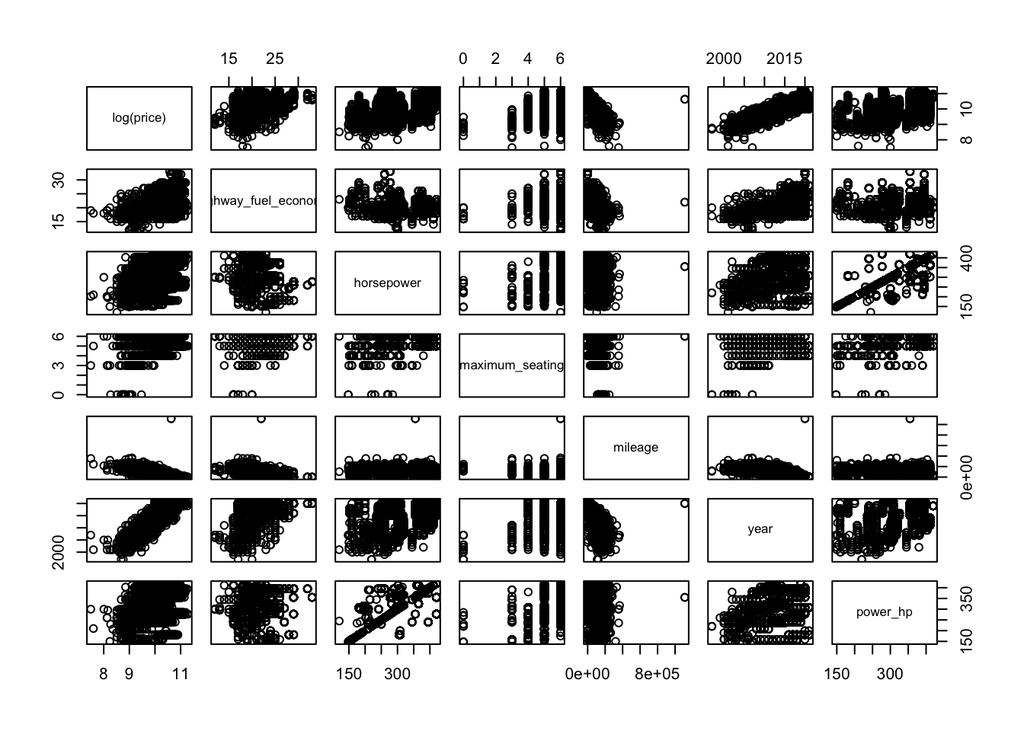

```r
pairs(log(price) ~ highway_fuel_economy + horsepower + maximum_seating + mileage + year + power_hp, data = cars_trn)
```

```r
fit_col = lm(log(price) ~ highway_fuel_economy + horsepower + maximum_seating +
    mileage + year + wheel_system + power_hp + bed_length + salvage +
    franchise_dealer + state + year:bed_length +
    year:mileage + maximum_seating:bed_length + highway_fuel_economy:maximum_seating + horsepower:year, data = cars_trn)


summary(fit_col)
```

```
##
## Call:
## lm(formula = log(price) ~ highway_fuel_economy + horsepower +
##     maximum_seating + mileage + year + wheel_system + power_hp +
##     bed_length + salvage + franchise_dealer + state + year:bed_length +
##     year:mileage + maximum_seating:bed_length + highway_fuel_economy:maximum_seating +
##     horsepower:year, data = cars_trn)
##
## Residuals:
##      Min       1Q   Median       3Q      Max
## -1.08890 -0.10848 -0.00168  0.10565  1.62195
##
## Coefficients:
##                                        Estimate Std. Error t value Pr(>|t|)
## (Intercept)                          -6.028e+01  8.118e+00  -7.426 1.20e-13 ***
## highway_fuel_economy                 -2.039e-02  6.556e-03  -3.110  0.00188 **
## horsepower                           -9.495e-02  1.506e-02  -6.306 2.97e-10 ***
## maximum_seating                      -2.937e-02  2.431e-02  -1.208  0.22704
## mileage                              -2.815e-04  1.564e-05 -18.003  < 2e-16 ***
## year                                  3.500e-02  4.054e-03   8.633  < 2e-16 ***
## wheel_system4X2                      -2.159e-01  4.854e-03 -44.481  < 2e-16 ***
## wheel_systemAWD                      -9.388e-02  1.211e-02  -7.754 9.62e-15 ***
## wheel_systemFWD                      -2.242e-01  5.165e-02  -4.341 1.43e-05 ***
## wheel_systemRWD                      -2.174e-01  1.782e-02 -12.202  < 2e-16 ***
## power_hp                              2.012e-04  3.853e-05   5.222 1.80e-07 ***
## bed_length                           -1.583e-01  1.183e-01  -1.338  0.18084
## salvageTRUE                          -2.183e-01  2.134e-02 -10.232  < 2e-16 ***
## franchise_dealerTRUE                  3.077e-02  4.960e-03   6.205 5.66e-10 ***
## stateCO                              -8.114e-03  4.500e-03  -1.803  0.07143 .
## stateID                              -8.917e-03  6.060e-03  -1.472  0.14118
## stateMT                              -6.626e-03  6.657e-03  -0.995  0.31959
## stateNM                               9.074e-03  5.895e-03   1.539  0.12377
## stateNV                               2.638e-02  5.433e-03   4.855 1.22e-06 ***
## stateUT                              -7.550e-03  5.504e-03  -1.372  0.17015
## stateWY                               4.005e-02  9.913e-03   4.040 5.37e-05 ***
## year:bed_length                       8.110e-05  5.909e-05   1.372  0.16995
## mileage:year                          1.386e-07  7.756e-09  17.869  < 2e-16 ***
## maximum_seating:bed_length           -1.848e-03  2.080e-04  -8.886  < 2e-16 ***
## highway_fuel_economy:maximum_seating  5.172e-03  1.134e-03   4.560 5.16e-06 ***
## horsepower:year                       4.779e-05  7.464e-06   6.403 1.58e-10 ***
## ---
## Signif. codes:  0 '***' 0.001 '**' 0.01 '*' 0.05 '.' 0.1 ' ' 1
##
## Residual standard error: 0.1623 on 11974 degrees of freedom
## Multiple R-squared:  0.8542, Adjusted R-squared:  0.8539
## F-statistic:  2805 on 25 and 11974 DF,  p-value: < 2.2e-16
```

```r
anova(fit_reduced2, fit_col)
```

```
## Analysis of Variance Table
##
## Model 1: log(price) ~ highway_fuel_economy + horsepower + maximum_seating +
##     mileage + year + wheel_system + power_hp + bed_length + salvage +
##     franchise_dealer + state
## Model 2: log(price) ~ highway_fuel_economy + horsepower + maximum_seating +
##     mileage + year + wheel_system + power_hp + bed_length + salvage +
##     franchise_dealer + state + year:bed_length + year:mileage +
##     maximum_seating:bed_length + highway_fuel_economy:maximum_seating +
##     horsepower:year
##   Res.Df    RSS Df Sum of Sq      F    Pr(>F)
## 1  11979 329.10
## 2  11974 315.27  5    13.829 105.05 < 2.2e-16 ***
## ---
## Signif. codes:  0 '***' 0.001 '**' 0.01 '*' 0.05 '.' 0.1 ' ' 1
```

```r
rmse(log(cars_trn$price), predict(fit_col, cars_trn))
```

```
## [1] 0.1620888
```

```r
rmse(log(cars_tst$price), predict(fit_col, cars_tst))
```

```
## [1] 0.1659061
```

```r
calc_loocv_rmse(fit_col)
```

```
## [1] 0.1634797
```

## Comparison

Comparing the models from the two regions, besides the common predictors, pacific region prefers engine_displacement, engine_cylinders, but doesn’t have state as predictor. Mountain region model prefers power_hp, salvage and state.